# Metric data: robustness and differences of ‘means’

Peter Ralph

5 February 2018 – Advanced Biological Statistics

# Overview

## Summary

So far we’ve focused on *discrete* data: coin flips and counts.

While doing that we came across familiar things, like Poisson regression.

This week we’ll look at *continuous* (i.e., “metric”) data. Different sorts of *predictors* will lead us to different classical statistics: linear regression, $t$-tests, etcetera.

But, control of the underlying model will let us easily get more sophisticated, including for instance robustness to error, and penalization for overdetermined problems.

# The basic ingredients

## Comparison of means

If the predictor, $X$, is *discrete* then we are doing a $t$-test, or ANOVA, or something.

Simulate data - difference in means of 3.0:

```r
truth <- list(b0=1.0, b1=3.0, sigma=0.5)
n <- 200
x <- sample(c(0, +1), size=n, replace=TRUE)
y <- truth$b0 + truth$b1 * x + rnorm(n, mean=0, sd=truth$sigma)
```

The $t$-test

```r
system.time( tt <- t.test(y ~ x) )
```

```
##    user  system elapsed
##   0.005   0.000   0.007
```

```r
tt
```

```
##
##  Welch Two Sample t-test
##
## data:  y by x
## t = -44.168, df = 193.19, p-value < 2.2e-16
## alternative hypothesis: true difference in means is not equal to 0
## 95 percent confidence interval:
##  -3.164550 -2.894004
## sample estimates:
## mean in group 0 mean in group 1
##       0.9611205       3.9903971
```

with Stan

```r
stt_block <- "
data {
    int N;
    vector[N] x; // will be a vector of 0's and 1's
    vector[N] y;
}
parameters {
    real b0;
    real b1;
    real<lower=0> sigma;
}
model {
    y ~ normal(b0 + b1*x, sigma);
}"
system.time( stantt <- stan(model_code=stt_block,
                            data=list(N=length(x), x=x, y=y), iter=1e3) )
```

```
##    user  system elapsed
##  40.240   0.978  42.754
```

```r
rstan::summary(stantt)
```

```
## $summary
##             mean      se_mean         sd       2.5%        25%        50%
## b0     0.9584959 0.0016430080 0.05127725  0.8597816  0.9234022  0.9588988
## b1     3.0320092 0.0022753493 0.06901506  2.8978689  2.9872654  3.0331521
## sigma  0.4863959 0.0006812764 0.02493617  0.4388088  0.4691070  0.4859912
## lp__  44.0727049 0.0419015047 1.24303922 40.8969349 43.4910938 44.4028637
##              75%      97.5%     n_eff     Rhat
## b0     0.9914469  1.0635215  974.0250 1.000422
## b1     3.0784012  3.1683381  920.0079 1.000391
## sigma  0.5024615  0.5372778 1339.7164 1.002857
## lp__  44.9781269 45.4684006  880.0562 1.001635
##
## $c_summary
## , , chains = chain:1
##
##          stats
## parameter       mean         sd       2.5%        25%        50%
##     b0     0.9561642 0.05454421  0.8437029  0.9217489  0.9589110
##     b1     3.0333137 0.07354142  2.8979076  2.9832068  3.0326182
##     sigma  0.4887660 0.02508591  0.4407525  0.4719735  0.4878538
##     lp__  43.9842256 1.28819655 40.8466789 43.3886738 44.3590545
##          stats
## parameter        75%      97.5%
##     b0     0.9922897  1.0620172
##     b1     3.0837845  3.1771981
##     sigma  0.5044771  0.5389809
##     lp__  44.8811333 45.4592424
##
## , , chains = chain:2
##
##          stats
## parameter       mean         sd       2.5%        25%        50%
##     b0     0.9587976 0.04814115  0.8637515  0.9255311  0.9596549
##     b1     3.0309562 0.06787379  2.9013071  2.9836336  3.0330067
##     sigma  0.4883044 0.02411460  0.4417797  0.4722400  0.4892917
##     lp__  44.1644344 1.22483135 40.9472576 43.6595758 44.4510361
##          stats
## parameter        75%      97.5%
##     b0     0.9883987  1.0561342
##     b1     3.0744157  3.1652904
```

[output cut: 17 more lines]

```
##
## , , chains = chain:4
##
##          stats
## parameter       mean         sd       2.5%        25%        50%
##     b0     0.9589962 0.04881229  0.8711463  0.9248723  0.9603675
##     b1     3.0308062 0.06793050  2.8955776  2.9887929  3.0333363
##     sigma  0.4846146 0.02519660  0.4378644  0.4666779  0.4828211
##     lp__  44.1251522 1.17581446 41.2491122 43.6387616 44.4166274
##          stats
## parameter        75%      97.5%
##     b0     0.9885910  1.0586022
##     b1     3.0787049  3.1610643
##     sigma  0.5010647  0.5335561
##     lp__  44.9715461 45.4541174
```

## Standard linear regression

Simulate data

```r
truth <- list(b0=1.0, b1=3.0, sigma=0.5)
n <- 200
x <- rnorm(n, mean=0, sd=3)
y <- ( truth$b0 + truth$b1 * x
        + rnorm(n, mean=0, sd=truth$sigma) )
```

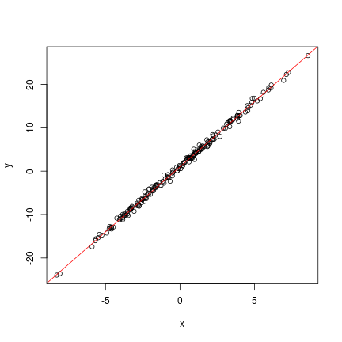

Standard linear regression

```r
system.time( slr <- lm(y ~ x) )
```

```
##    user  system elapsed
##   0.003   0.000   0.003
```

```r
summary(slr)
```

```
##
## Call:
## lm(formula = y ~ x)
##
## Residuals:
##      Min       1Q   Median       3Q      Max
## -1.39045 -0.32827  0.00434  0.33770  1.29782
##
## Coefficients:
##             Estimate Std. Error t value Pr(>|t|)
## (Intercept)  1.03743    0.03511   29.55   <2e-16 ***
## x            2.99838    0.01114  269.08   <2e-16 ***
## ---
## Signif. codes:  0 '***' 0.001 '**' 0.01 '*' 0.05 '.' 0.1 ' ' 1
##
## Residual standard error: 0.4964 on 198 degrees of freedom
## Multiple R-squared:  0.9973, Adjusted R-squared:  0.9973
## F-statistic: 7.24e+04 on 1 and 198 DF,  p-value: < 2.2e-16
```

with Stan

```r
slr_block <- "
data {
    int N;
    vector[N] x;
    vector[N] y;
}
parameters {
    real b0;
    real b1;
    real<lower=0> sigma;
}
model {
    y ~ normal(b0 + b1*x, sigma);
}"
system.time( stanlr <- stan(model_code=slr_block,
                            data=list(N=length(x), x=x, y=y), iter=1e3) )
```

```
##    user  system elapsed
##   0.353   0.021   4.764
```

```r
rstan::summary(stanlr)
```

```
## $summary
##            mean      se_mean         sd       2.5%       25%        50%
## b0     1.037869 0.0007832024 0.03445802  0.9713526  1.014941  1.0375510
## b1     2.998214 0.0002726515 0.01091294  2.9762261  2.991127  2.9983839
## sigma  0.499058 0.0005992648 0.02528762  0.4519479  0.481801  0.4974935
## lp__  38.915232 0.0365957577 1.15005479 35.8583462 38.361609 39.2207213
##              75%      97.5%     n_eff      Rhat
## b0     1.0614043  1.1055692 1935.6758 0.9986115
## b1     3.0058555  3.0190104 1602.0198 0.9990105
## sigma  0.5155453  0.5513456 1780.6489 0.9992986
## lp__  39.7494696 40.2749670  987.5875 1.0029886
##
## $c_summary
## , , chains = chain:1
##
##          stats
## parameter       mean          sd       2.5%        25%        50%
##     b0     1.0367225 0.034279995  0.9669801  1.0117994  1.0382511
##     b1     2.9979769 0.009875374  2.9770437  2.9919000  2.9980638
##     sigma  0.4990248 0.024079538  0.4564641  0.4826994  0.4972312
##     lp__  39.0575615 1.022991990 36.6202467 38.5023542 39.3546764
##          stats
## parameter        75%      97.5%
##     b0     1.0609250  1.0998919
##     b1     3.0047203  3.0161260
##     sigma  0.5143986  0.5517112
##     lp__  39.8186780 40.2877270
##
## , , chains = chain:2
##
##          stats
## parameter       mean         sd       2.5%        25%        50%
##     b0     1.0373640 0.03561805  0.9728951  1.0134970  1.0373803
##     b1     2.9980877 0.01138842  2.9769848  2.9901239  2.9980656
##     sigma  0.4979226 0.02372709  0.4550867  0.4824173  0.4958306
##     lp__  38.9026250 1.17136079 35.9881874 38.4118545 39.2227635
##          stats
## parameter        75%      97.5%
##     b0     1.0610916  1.1057651
##     b1     3.0066883  3.0183298
```

[output cut: 17 more lines]

```
##
## , , chains = chain:4
##
##          stats
## parameter       mean         sd       2.5%        25%       50%        75%
##     b0     1.0390416 0.03494682  0.9708443  1.0154732  1.037488  1.0639421
##     b1     2.9982554 0.01053387  2.9766606  2.9917165  2.998576  3.0052957
##     sigma  0.4994534 0.02715986  0.4467995  0.4794095  0.499711  0.5181878
##     lp__  38.8457266 1.20606007 35.6770810 38.3080068 39.131457 39.7021003
##          stats
## parameter      97.5%
##     b0     1.1060811
##     b1     3.0179989
##     sigma  0.5519271
##     lp__  40.2863087
```

## Multivariate linear regrssion

Simulate data:

```r
truth <- list(b0=1.0,
              b=c(3.0, -1.0, 0.0, 0.0),
              sigma=0.5)
n <- 200
x <- matrix(rnorm(4*n, mean=0, sd=3), ncol=4)
y <- truth$b0 + x %*% truth$b + rnorm(n, mean=0, sd=truth$sigma)
```

**Your turn:** compare standard multivariate regression to Stan.

*Note:* `%*%` in R, and `*` in Stan, are *matrix multiplication*.

Standard linear regression

```r
system.time( mlr <- lm(y ~ x) )
```

```
##    user  system elapsed
##   0.002   0.000   0.001
```

```r
summary(mlr)
```

```
##
## Call:
## lm(formula = y ~ x)
##
## Residuals:
##      Min       1Q   Median       3Q      Max
## -1.41425 -0.31589  0.01571  0.33286  1.74978
##
## Coefficients:
##              Estimate Std. Error t value Pr(>|t|)
## (Intercept)  0.964532   0.037556  25.683   <2e-16 ***
## x1           3.013153   0.012082 249.402   <2e-16 ***
## x2          -0.981735   0.013644 -71.956   <2e-16 ***
## x3           0.001413   0.013201   0.107    0.915
## x4           0.005444   0.011416   0.477    0.634
## ---
## Signif. codes:  0 '***' 0.001 '**' 0.01 '*' 0.05 '.' 0.1 ' ' 1
##
## Residual standard error: 0.5269 on 195 degrees of freedom
## Multiple R-squared:  0.997,  Adjusted R-squared:  0.9969
## F-statistic: 1.614e+04 on 4 and 195 DF,  p-value: < 2.2e-16
```

with Stan

```r
mlr_block <- "
data {
    int N;
    matrix[N,4] x;
    vector[N] y;
}
parameters {
    real b0;
    vector[4] b1;
    real<lower=0> sigma;
}
model {
    y ~ normal(to_vector(b0 + x * b1), sigma);
    b0 ~ normal(0, 10);
    b1 ~ normal(0, 10);
    sigma ~ normal(0, 10);
}"
system.time( stanmlr <- stan(model_code=mlr_block,
                            data=list(N=nrow(x), x=x,
                                      y=as.vector(y)), iter=1e3) )
```

```
##    user  system elapsed
##  36.700   0.754  39.127
```

```r
rstan::summary(stanmlr)
```

```
## $summary
##               mean      se_mean         sd        2.5%          25%
## b0     0.964168876 0.0008609641 0.03850349  0.88884240  0.939406253
## b1[1]  3.013312508 0.0002716845 0.01215010  2.99088002  3.004693625
## b1[2] -0.981814139 0.0003059612 0.01368300 -1.00843766 -0.990836467
## b1[3]  0.001582385 0.0002901135 0.01297427 -0.02414813 -0.007005947
## b1[4]  0.004641061 0.0002539090 0.01135515 -0.01752785 -0.003051936
## sigma  0.529757796 0.0005968461 0.02669177  0.48294737  0.510904188
## lp__  26.980574920 0.0591634454 1.73877680 22.52377782 26.065571894
##                50%         75%       97.5%     n_eff      Rhat
## b0     0.963721191  0.98890566  1.04202257 2000.0000 0.9998817
## b1[1]  3.013401938  3.02162108  3.03658448 2000.0000 0.9995003
## b1[2] -0.981705463 -0.97276853 -0.95519086 2000.0000 0.9998914
## b1[3]  0.001302625  0.01037515  0.02706174 2000.0000 0.9990247
## b1[4]  0.004710580  0.01223199  0.02721156 2000.0000 0.9985843
## sigma  0.528650061  0.54710170  0.58528911 2000.0000 1.0021144
## lp__  27.275462315 28.26884818 29.30228460  863.7355 1.0021258
##
## $c_summary
## , , chains = chain:1
##
##          stats
## parameter         mean         sd        2.5%          25%          50%
##     b0     0.965489164 0.03704322  0.89244744  0.941751021  0.965325283
##     b1[1]  3.013113234 0.01218186  2.99019878  3.003942192  3.012948908
##     b1[2] -0.980972706 0.01429928 -1.00831464 -0.989874077 -0.981252601
##     b1[3]  0.001954729 0.01326935 -0.02370373 -0.006891810  0.001518715
##     b1[4]  0.004267654 0.01248824 -0.02003368 -0.002961459  0.004026469
##     sigma  0.530161630 0.02618649  0.48441958  0.511656124  0.529157268
##     lp__  26.892122057 1.86887860 22.29523081 26.018117229 27.271768512
##          stats
## parameter         75%       97.5%
##     b0     0.99094337  1.04145311
##     b1[1]  3.02167827  3.03497667
##     b1[2] -0.97236903 -0.95061024
##     b1[3]  0.01051886  0.02815576
##     b1[4]  0.01167012  0.02887848
##     sigma  0.54668856  0.58473576
##     lp__  28.24984013 29.31057866
##
```

[output cut: 47 more lines]

```
##     b1[1]  3.013196445 0.01234384  2.98860738  3.004647147  3.013449878
##     b1[2] -0.982586764 0.01346876 -1.00882031 -0.992128027 -0.982204177
##     b1[3]  0.002057692 0.01283640 -0.02349400 -0.005717890  0.001772736
##     b1[4]  0.004576544 0.01078270 -0.01722273 -0.003643438  0.004868278
##     sigma  0.527117742 0.02783492  0.47745834  0.507373992  0.526057944
##     lp__  26.994287764 1.57074798 23.49262217 26.053048026 27.190228323
##          stats
## parameter         75%       97.5%
##     b0     0.99085690  1.04217216
##     b1[1]  3.02093133  3.03652066
##     b1[2] -0.97302255 -0.95851713
##     b1[3]  0.01081647  0.02662559
##     b1[4]  0.01237443  0.02409439
##     sigma  0.54459562  0.59317977
##     lp__  28.21249435 29.28008931
```

# Testing with crossvalidation

## Crossvalidation

Just because a model *fits* doesn’t mean that it’s any *good*.

1. Divide your data randomly into 5 pieces.
2. Fit your model on 4/5ths, and see how well it predicts the remaining 1/5th.
3. Do this for each of the 5 pieces.

A better model should have better *crossvalidation accuracy*.

**Question:** for linear regression, how do we “see how well it predicts”? Write down the math, then code it up.

```r
five_groups <- sample(rep(1:5, each=nrow(x)/5))

do_crossval <- function (k) {
    # fit using not group k
    subset_lm <- lm( y ~ x, subset=(five_groups != k))
    # predict on group k
    yhat <- predict(subset_lm,
                    newdata=list(x=x[five_groups == k,]))
    # compute crossvalidation accuracy
    S <- sqrt( mean( ( y[five_groups == k] - yhat  )^2 ) )
    return(S)
}

crossvals <- sapply(1:5, do_crossval)
```

The mean crossvalidation score for ordinary linear regression was 0.5403888, with a standard deviation of 0.070462.

## What is overfitting?

Even completely independent sets of numbers will correlate a little, because of noise.

When you have a *lot* of variables, there may be some that correlate well with the response variable just by chance.

If you have as many variables than observations, then there is (almost) *always* a linear model that fits *perfectly* (with $\epsilon = 0$).

*Example:*

```r
nvars <- 200
truth <- list(b0=1.0,
              b=rep(0.0, nvars),
              sigma=0.5)
n <- 200
x <- matrix(rnorm(nvars*n, mean=0, sd=3), ncol=nvars)
y <- truth$b0 + x %*% truth$b + rnorm(n, mean=0, sd=truth$sigma)
the_lm <- lm(y ~ x)
range(predict(the_lm) - y)
```

```
## [1] -5.750955e-14  6.311618e-14
```

# Stochastic minute

If $X \sim \Cauchy(\text{center}=\mu, \text{scale}=\sigma)$, then $X$ has probability density
$$\begin{aligned}
f(x \given \mu, \sigma) = \frac{1}{\pi\left( 1 + \left( \frac{x - \mu}{\sigma} \right)^2 \right)} .
\end{aligned}$$

1. The Cauchy is a good example of a distribution with “heavy tails”: rare, very large values.
2. If $Y$ and $Z$ are independent $\Normal(0,1)$ then $Y/Z \sim \Cauchy(0,1)$.
3. If $X_1, X_2, \ldots, X_n$ are independent $\Cauchy(0,1)$ then $\max(X_1, \ldots, X_n)$ is of size $n$.
4. Also, $\frac{1}{n}(X_1 + \ldots + X_n) \sim \Cauchy(0,1)$.
4. If $X_1, X_2, \ldots, X_n$ are independent $\Cauchy(0,1)$ then
   $$\begin{aligned}
   \frac{1}{n} \left(X_1 + \cdots + X_n\right) \sim \Cauchy(0,1) .
   \end{aligned}$$

*Wait, what?!?*

A single value has the *same distribution* as the mean of 1,000 of them?

Let’s look:

```r
meanplot <- function (rf, n=1e3, m=100) {
    x <- matrix(rf(n*m), ncol=m)
    layout(t(1:2))
    hist(x[1,][abs(x[1,])<5], breaks=20, freq=FALSE,
         main=sprintf("%d samples", m),
         xlim=c(-5,5))
    hist(colMeans(x)[abs(colMeans(x))<5], breaks=20, freq=FALSE,
         main=sprintf("%d means of %d each", m, n),
         xlim=c(-5,5))
}
```

$X \sim \Normal(0,1)$

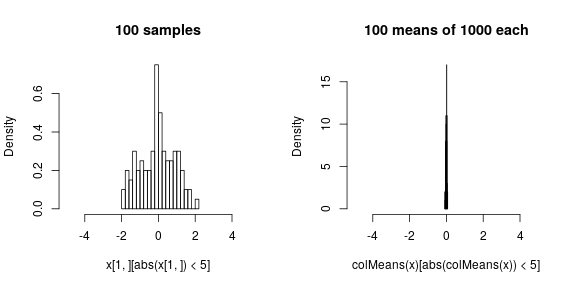

```r
meanplot(rnorm)
```

$X \sim \Cauchy(0,1)$

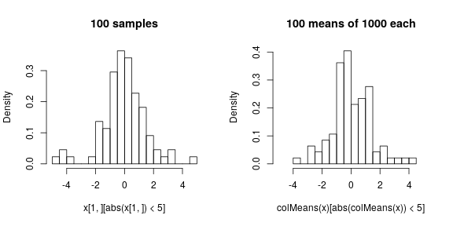

```r
meanplot(rcauchy)
```

## Another way to look at it: extreme values

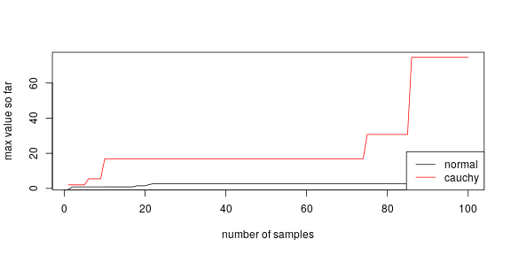

```r
n <- 100
plot(c(cummax(rcauchy(n))), type='l', ylab='max value so far', xlab='number of samples', col='red')
lines(c(cummax(rnorm(n))), col='black')
legend("bottomright", lty=1, col=c('black', 'red'), legend=c('normal', 'cauchy'))
```

## Another way to look at it: extreme values

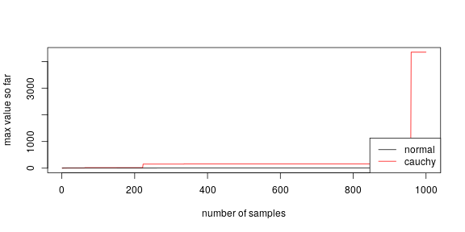

```r
n <- 1000
plot(c(cummax(rcauchy(n))), type='l', ylab='max value so far', xlab='number of samples', col='red')
lines(c(cummax(rnorm(n))), col='black')
legend("bottomright", lty=1, col=c('black', 'red'), legend=c('normal', 'cauchy'))
```

## Another way to look at it: extreme values

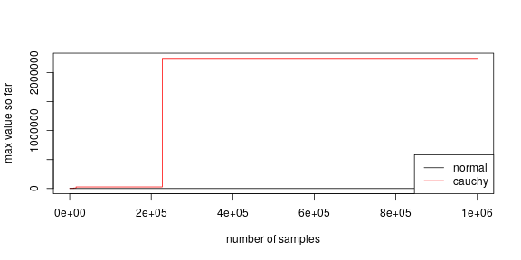

```r
n <- 1e6
plot(c(cummax(rcauchy(n))), type='l', ylab='max value so far', xlab='number of samples', col='red')
lines(c(cummax(rnorm(n))), col='black')
legend("bottomright", lty=1, col=c('black', 'red'), legend=c('normal', 'cauchy'))
```

# Problem #1: noise

## Cauchy noise

Let’s see what happens if
$$\begin{aligned}
Y_i &= b_0 + b_1 X_1 + \epsilon_i \\
\epsilon_i &\sim \Cauchy(0, \sigma) .
\end{aligned}$$

```r
truth <- list(b0=1.0, b1=3.0, sigma=0.5)
n <- 1000
x <- sample(c(0, +1), size=n, replace=TRUE)
y <- truth$b0 + truth$b1 * x + rcauchy(n, location=0, scale=truth$sigma)
```

The $t$-test

```r
system.time( tt <- t.test(y ~ x) )
```

```
##    user  system elapsed
##   0.005   0.000   0.005
```

```r
tt
```

```
##
##  Welch Two Sample t-test
##
## data:  y by x
## t = -0.5875, df = 904.03, p-value = 0.557
## alternative hypothesis: true difference in means is not equal to 0
## 95 percent confidence interval:
##  -2.779966  1.499041
## sample estimates:
## mean in group 0 mean in group 1
##        2.537384        3.177847
```

with Stan

```r
sct_block <- "
data {
    int N;
    vector[N] x; // will be a vector of 0's and 1's
    vector[N] y;
}
parameters {
    real b0;
    real b1;
    real<lower=0> sigma;
}
model {
    y ~ cauchy(b0 + b1*x, sigma);
}"
system.time( stanct <- stan(model_code=sct_block,
                            data=list(N=length(x), x=x, y=y), iter=1e3) )
```

```
##    user  system elapsed
##  36.315   0.833  42.321
```

```r
rstan::summary(stanct)
```

```
## $summary
##               mean      se_mean         sd        2.5%          25%
## b0       1.0291922 0.0011314808 0.03548784    0.960985    1.0044436
## b1       2.9313917 0.0016139906 0.04953027    2.833088    2.8983148
## sigma    0.5246031 0.0006601783 0.02314277    0.481779    0.5086437
## lp__  -728.2095555 0.0491822653 1.29123990 -731.396073 -728.8063460
##                50%          75%        97.5%     n_eff      Rhat
## b0       1.0295111    1.0533330    1.0994354  983.7046 0.9991930
## b1       2.9325418    2.9645720    3.0299830  941.7582 0.9997976
## sigma    0.5245932    0.5401948    0.5702207 1228.8759 1.0033877
## lp__  -727.8744378 -727.2580625 -726.7144310  689.2818 1.0019354
##
## $c_summary
## , , chains = chain:1
##
##          stats
## parameter         mean         sd         2.5%          25%          50%
##     b0       1.0296636 0.03459815    0.9696624    1.0038920    1.0285112
##     b1       2.9317775 0.04820848    2.8307235    2.9032111    2.9355758
##     sigma    0.5271417 0.02222283    0.4881341    0.5122751    0.5252849
##     lp__  -728.1911557 1.29963400 -731.4383352 -728.7771593 -727.8187576
##          stats
## parameter          75%        97.5%
##     b0       1.0526276    1.0937105
##     b1       2.9618142    3.0210954
##     sigma    0.5409076    0.5757164
##     lp__  -727.2403446 -726.7335290
##
## , , chains = chain:2
##
##          stats
## parameter         mean         sd         2.5%          25%          50%
##     b0       1.0300621 0.03471651    0.9617799    1.0053069    1.0320335
##     b1       2.9287701 0.04875061    2.8307552    2.8946702    2.9309229
##     sigma    0.5252629 0.02262749    0.4834991    0.5093539    0.5248081
##     lp__  -728.1085467 1.26765283 -731.3837532 -728.6215158 -727.7928074
##          stats
## parameter          75%        97.5%
##     b0       1.0538801    1.1024453
##     b1       2.9623883    3.0256776
```

[output cut: 17 more lines]

```
##
## , , chains = chain:4
##
##          stats
## parameter         mean         sd         2.5%          25%          50%
##     b0       1.0297237 0.03747682    0.9515017    1.0037207    1.0294222
##     b1       2.9332261 0.05224475    2.8352613    2.8997922    2.9281443
##     sigma    0.5243002 0.02358604    0.4819830    0.5070324    0.5253618
##     lp__  -728.3453999 1.34219529 -731.6390165 -729.0326680 -728.0149964
##          stats
## parameter          75%        97.5%
##     b0       1.0561818    1.1026390
##     b1       2.9688785    3.0367147
##     sigma    0.5401849    0.5708525
##     lp__  -727.3210549 -726.6999041
```

Because we *correctly model* the noise, using Stan, we are not thrown off by large values.

# Robust ANOVA

## Metric data from groups

Suppose we have numerical observations coming from $m$ different groups, and want to know if the *means* are different between groups, and by how much.

```r
m <- 20
truth <- list(b=200 + rnorm(m, sd=5),
              sigma=2.0)
n <- 200
x <- sample(1:m, size=n, replace=TRUE)
y <- pmax(0, truth$b[x]
              + rcauchy(n, location=0,
                      scale=truth$sigma) )
```

```r
boxplot(y ~ x, main='all data')
points(seq_along(truth$b), truth$b, pch=20, cex=2.0, col='red')
boxplot(y ~ x, subset=abs(y-200)<20, xlab='treatment', main='abs(y-200) < 10')
points(seq_along(truth$b), truth$b, pch=20, cex=2.0, col='red')
```

[output not shown]

Each group has a different location and scale; noise about these is Cauchy; group locations are random deviations; group scale parameters are random deviations from a common scale.

$$\begin{aligned}
Y_i &\sim \Cauchy(b_{g_i}, \sigma_{g_i}) \\
\sigma_g &\sim \log\Normal(\mu, 1) \\
b_g &\sim \Normal(0, \eta) \\
\eta &\sim \Normal(0, 15) \\
\mu &\sim \Normal(0, 1)
\end{aligned}$$

*Changes:*

1. Added common mean, $z$.
2. Put “shrinkage” prior on $\mu$.

```r
anova_block <- "
data {
    int N; // number of obs
    int m; // number of groups
    vector[N] y; // leaf mass
    int g[N]; // group ID
}
parameters {
    vector[m] b;  // group 'means'
    real z;  // overall mean
    // group 'SD's
    vector<lower=0>[m] sigma;
    // variability in group means
    real<lower=0> eta;
    // log-mean of sigma
    real mu;
}
model {
    y ~ cauchy(b[g], sigma[g]);
    // lognormal, encouraging all group sigmas to be the same,
    // but trying not to constrain them if they want to be different
    sigma ~ lognormal(mu, 1);
    // unsure of scale for b,
    // so put a hyperprior on it
    b ~ normal(z, eta);
    z ~ normal(0, 15);
    eta ~ normal(0, 15);
    // encourage mu to be near zero if reasonable
    mu ~ exponential(1);
}"

## note we subtract the median of y
anova_data <- list(N=length(y),
                   m=length(unique(x)),
                   y=y - median(y),
                   g=x)

anova_fit <- stan(model_code=anova_block,
                  data=anova_data,
                  iter=1e3,
                  control=list(adapt_delta=0.99))
rstan::summary(anova_fit)
```

```
## $summary
##                   mean     se_mean        sd          2.5%          25%
## b[1]         2.0004977 0.060226283 2.4055064 -2.548039e+00    0.5329497
## b[2]         3.8144570 0.020915938 0.9353892  2.066095e+00    3.1516557
## b[3]        -5.7398166 0.030528892 1.3652936 -8.577400e+00   -6.5666481
## b[4]        -6.0629232 0.113239374 3.8691468 -1.146395e+01   -9.0973767
## b[5]         2.6730416 0.073261829 2.6358666 -3.047754e+00    1.2429469
## b[6]         7.3137300 0.037505761 1.4435569  4.030945e+00    6.5016253
## b[7]        -1.9352014 0.026194048 0.8962760 -3.482414e+00   -2.4739148
## b[8]        -6.7625511 0.026930714 1.0678358 -8.534017e+00   -7.4462092
## b[9]        -9.3529212 0.016674325 0.7456985 -1.076861e+01   -9.8430554
## b[10]       -0.9128103 0.031145738 1.2559245 -3.471611e+00   -1.6279343
## b[11]       -0.7444011 0.036753731 1.3239965 -3.608819e+00   -1.4710115
## b[12]       -5.1873019 0.023807518 0.7926762 -6.751619e+00   -5.6460311
## b[13]        2.6825066 0.022497768 0.8931097  6.314364e-01    2.1892071
## b[14]        6.6480984 0.082148658 1.8631067  1.888808e+00    6.3080801
## b[15]        6.7591424 0.018793675 0.7710591  5.299906e+00    6.2701552
## b[16]       -1.2011538 0.039757111 1.5286743 -4.259362e+00   -2.1498786
## b[17]        1.6801114 0.024140282 0.8950193  1.348572e-01    1.0918949
## b[18]        5.3025488 0.021110648 0.9440969  3.232415e+00    4.7801497
## b[19]       -1.2398895 0.021077778 0.9426269 -3.156877e+00   -1.8406593
## b[20]        3.0965591 0.046225322 1.4624299  1.106025e-03    2.2716071
## z            0.1980326 0.028923300 1.2934893 -2.370657e+00   -0.6344199
## sigma[1]     6.7592524 0.065289636 2.9198413  2.633624e+00    4.6987140
## sigma[2]     1.7238744 0.019495772 0.7889384  6.991711e-01    1.1826245
## sigma[3]     3.6843377 0.027070229 1.2106175  1.827846e+00    2.8446029
## sigma[4]     5.8745465 0.097619356 3.6738025  1.371243e+00    3.4116733
## sigma[5]     6.8143446 0.120401297 4.2525121  1.915057e+00    3.7804684
## sigma[6]     2.2300302 0.026557779 1.0971283  7.607752e-01    1.4594705
## sigma[7]     1.8058863 0.030570861 1.0300583  5.323175e-01    1.1044089
## sigma[8]     2.3876930 0.025597703 1.1447641  8.645015e-01    1.5827505
## sigma[9]     1.9491344 0.014723320 0.6584469  9.432482e-01    1.4563038
## sigma[10]    2.7461600 0.045705377 1.6757890  8.587729e-01    1.6454605
## sigma[11]    2.8846814 0.031913402 1.4272107  1.040292e+00    1.9280316
## sigma[12]    1.8356603 0.026778170 0.9339195  6.702639e-01    1.1715258
## sigma[13]    1.9138968 0.024162875 0.9487308  6.743648e-01    1.2724416
## sigma[14]    1.6457907 0.082139713 2.0317448  1.867137e-01    0.5347309
## sigma[15]    2.0410611 0.016453656 0.7358298  9.389705e-01    1.5109605
## sigma[16]    4.6449526 0.044763812 2.0018985  1.966467e+00    3.2362394
## sigma[17]    2.0591803 0.024054311 0.9756655  7.397800e-01    1.3800453
```

[output cut: 417 more lines]

```
##   sigma[9]     2.38419882    3.6484986
##   sigma[10]    3.08967825    6.3953078
##   sigma[11]    3.57021494    6.1041079
##   sigma[12]    2.23644001    3.5935179
##   sigma[13]    2.19566927    3.9035105
##   sigma[14]    1.74438459    5.4041139
##   sigma[15]    2.42096303    3.7803624
##   sigma[16]    5.79601574   10.3939511
##   sigma[17]    2.48950850    4.0881436
##   sigma[18]    2.64090199    4.7544966
##   sigma[19]    2.50103226    3.9335365
##   sigma[20]    3.04546092    6.2119047
##   eta          6.07962299    7.9041645
##   mu           0.98097561    1.2638856
##   lp__      -509.95864231 -505.2163494
```

*What do we want to know?*

1. Do the treatments affect mean growth?
2. How much does leaf mass in treatment 8 differ from group 12?
3. How much variation is explained by treatment?

*How do we find it out?*

1. See if any credible intervals overlap? And, see if credible interval for eta > 0.
2. Posterior distribution of `b[12] - b[8]`: if `>0` then `b[12] > b[8]`; if zero is in it then `b[12] = b[8]`.
3. Compare `sigma` to `eta`. Or take the ratio of MADs before and after subtracting `b[-]`.

## Do treatments affect growth?

First let’s simply see if the credible intervals overlap. Many of these don’t overlap even close, so it sure looks like some of the treatments were different from other ones.

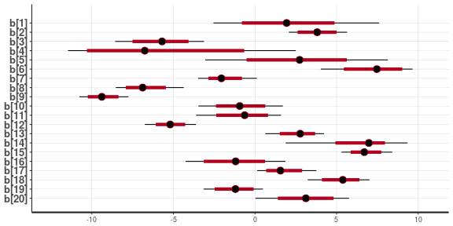

```r
quietgg(stan_plot(anova_fit, pars="b"))
```

Now, let’s look at `eta`, which is the SD parameter on the prior for `b`, the group location parameters. If `eta` is zero, then all the `b`s are the same.

It looks like `eta` has a wide posterior distribution, but all the posterior support is quite far from zero, indicating that the group locations are different between the groups.

```r
rstan::summary(anova_fit, pars="eta")$summary
```

```
##         mean    se_mean     sd     2.5%      25%      50%      75%
## eta 5.468179 0.02758036 1.0167 3.846221 4.766442 5.325984 6.060594
##        97.5%    n_eff      Rhat
## eta 7.872626 1358.895 0.9994464
```

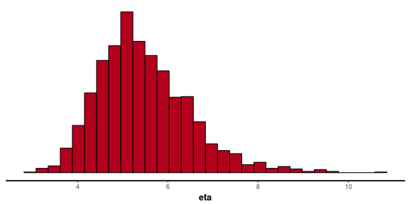

```r
stan_hist(anova_fit, pars="eta", bins=30)
```

## How much do treatments 8 and 12 differ?

Here we look at the posterior distribution of `b[12] - b[8]`.

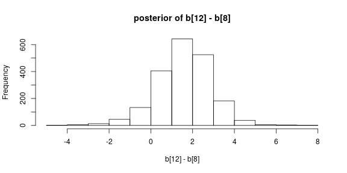

```r
bsamps <- extract(anova_fit)$b
diff_samps <- bsamps[,12] - bsamps[,8]
hist(diff_samps, main="posterior of b[12] - b[8]", xlab='b[12] - b[8]')
```

The posterior mean difference is 1.5752492 but a 95% credible interval goes from -1.1545359 to 3.9845409. Since zero is in the credible interval, we can’t really tell from the data if there is a real difference here, but if there is, it’s probably less than 5 or so.

## How much variation is explained by treatment?

We want to compare `eta` (which describes how much different treatments affect leaf mass) to the values of `sigma` (which describe how much leaf mass varies within each treatment).

First we need to check how much `sigma` vary.

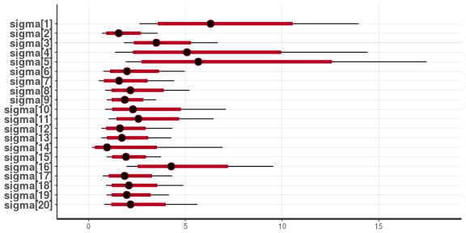

```r
quietgg(stan_plot(anova_fit, pars="sigma"))
```

The posterior distributions of different groups’ sigma values overlap a lot; so we’ll look at the posterior distribution of the mean sigma value to describe how much within-group variation there is.

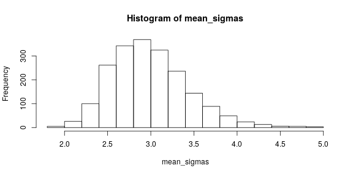

```r
mean_sigmas <- rowMeans(extract(anova_fit, pars="sigma")$sigma)
hist(mean_sigmas)
```

It looks like `sigma` is between 2 and 4, roughly.

We really want to know how big `eta` tends to be relative to `sigma`

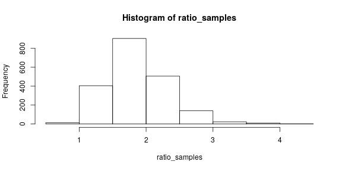

```r
eta_samples <- extract(anova_fit)$eta
ratio_samples <- eta_samples / mean_sigmas
hist(ratio_samples)
```

The posterior mean ratio of `eta` to `sigma` is 1.8691119, with a 95% credible interval of 1.1587616 to 2.8474252. In other words, it looks like differences in leaf mass between treatments are almost twice the typical differences between plants that had the same treatment.